# Analysis activity from Fitbit

Javier Rey

18 de agosto de 2015

## Synopsis

I study the specialization of data science at Coursera and what better way to apply learning doing things real.

I will try subjects as:

- Web scraping
- read data
- tidy data
- transform data
- measures of tendency central
- plots and so on.

I hope that this document can help to someone on the way of the data sciences.

Nothing of this would possible without the contribution of all people that they have created the awesome packages for R.

## American heart Association

Being physically active is important to prevent heart disease and stroke, the nation’s No. 1 and No. 5 killers. To improve overall cardiovascular health, we suggest at least 150 minutes per week of moderate exercise or 75 minutes per week of vigorous exercise (or a combination of moderate and vigorous activity). Thirty minutes a day, five times a week is an easy goal to remember. You will also experience benefits even if you divide your time into two or three segments of 10 to 15 minutes per day.

For people who would benefit from lowering their blood pressure or cholesterol, we recommend 40 minutes of aerobic exercise of moderate to vigorous intensity three to four times a week to lower the risk for heart attack and stroke.

More information in:

http://www.heart.org/HEARTORG/GettingHealthy/PhysicalActivity/FitnessBasics/American-Heart-Association-Recommendations-for-Physical-Activity-in-Adults_UCM_307976_Article.jsp

## Load library for sign on and get data from Fitbit

```r
library(fitbitScraper)

# Note: add this line in other sources:
# cookie <- login("myemail@myemail.com", "mypassword", rememberMe = TRUE)
data <- get_daily_data(cookie, what="steps", start_date="2015-02-24",
                       end_date="2015-08-17")

str(data)
```

```
## 'data.frame':    175 obs. of  2 variables:
##  $ time : POSIXct, format: "2015-02-24" "2015-02-25" ...
##  $ steps: num  137 6859 6047 8985 8468 ...
```

```r
dim(data)
```

```
## [1] 175   2
```

```r
sum(is.na(data))
```

```
## [1] 0
```

## Processing data

```r
data$month <- as.numeric(format(data$time, "%m"))
library(dplyr)
group_data <- summarise(group_by(data, month), mean = mean(steps), sd = sd(steps), median = median(steps), variance = var(steps))

group_data
```

```
## Source: local data frame [7 x 5]
##
##   month     mean       sd median variance
## 1     2 6099.200 3537.899   6859 12516726
## 2     3 6796.613 3885.797   7643 15099417
## 3     4 1751.233 3188.206      0 10164656
## 4     5 7322.645 2634.182   7580  6938917
## 5     6 8026.300 3560.974   8051 12680533
## 6     7 6956.968 2837.603   7655  8051989
## 7     8 6448.471 3389.543   6554 11488999
```

## Results - plots with visualization about steps in months

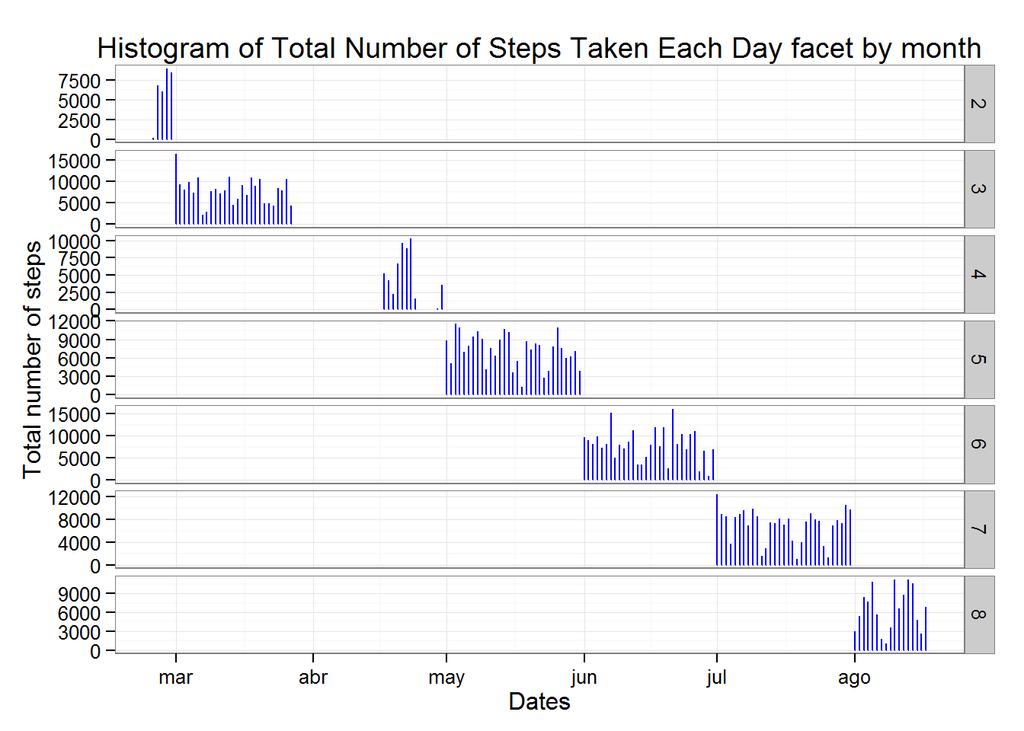

```r
library(ggplot2)
graph <- ggplot(data, aes(time, steps))
graph <- graph + geom_bar(stat = "identity", colour = "Blue", width = 0.7)
graph <- graph + facet_grid(month ~ ., scales = "free")
graph <- graph + labs(title = "Histogram of Total Number of Steps Taken Each Day facet by month", x = "Dates", y = "Total number of steps")
# override the theme
theme_set(theme_bw())
graph
```

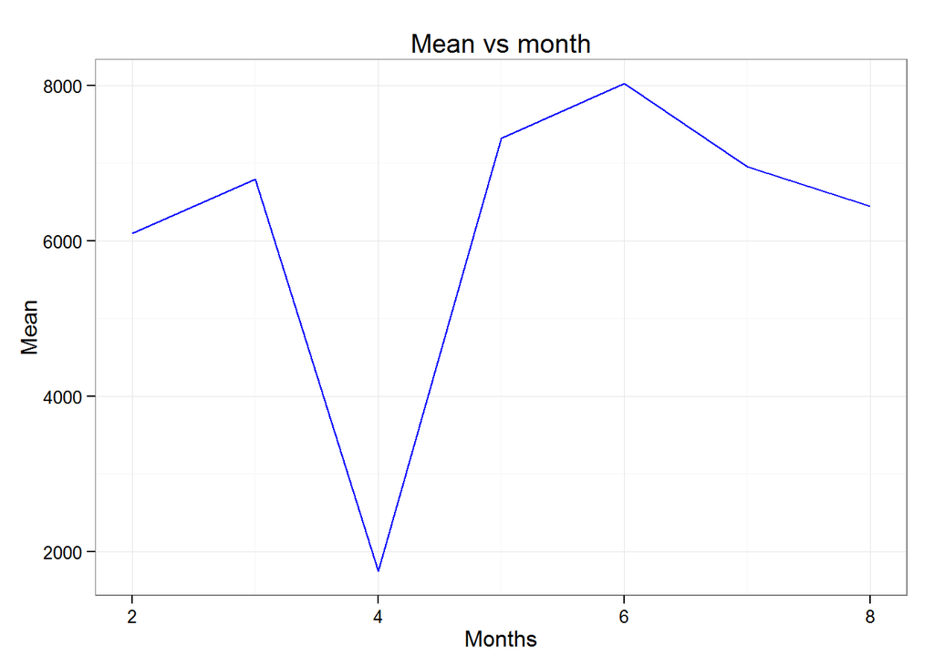

```r
graph <- ggplot(group_data, aes(x=month, y=mean))
graph <- graph + geom_line(colour = "Blue")
graph <- graph + labs(title = "Mean vs month", x = "Months", y = "Mean")
graph
```

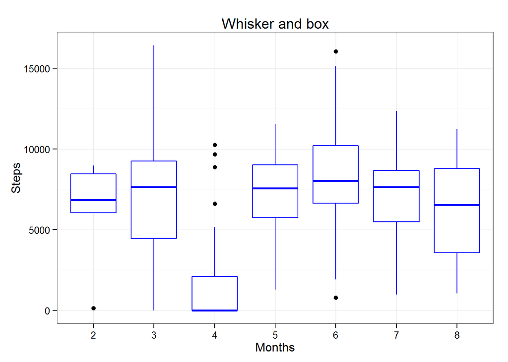

```r
graph <- ggplot(data, aes(x=factor(month), y=steps))
graph <- graph + geom_boxplot(colour = "Blue")
graph <- graph + labs(title = "Whisker and box", x = "Months", y = "Steps")
graph
```